# Lab 4 Modeling With Rasters

Griffin Shelor

Sept 21, 2023

The USGS conducted extensive surveys of the Gold butte Area in southern Nevada. These surveys were conducted to understand the distribution patterns of many species in the area, and the relative risk of wildfire in the area.

## Question 1

1. Load the Gold Butte Boundary (GB_Bdry from the Lab 4 Folder) and the “Gold Butte observed species” files. b) Plot the observed species and the Gold Butte boundary c) symbolizing each species (in the ObservedSp column) with different colored filled triangles using one of the color palette packages that allow for enough unique colors.

```r
GB_Boundary <- vect("GoldButte/GB_Bdry.shp")
crs(GB_Boundary, describe = T)
```

```
##                   name authority  code area         extent
## 1 NAD83 / UTM zone 11N      EPSG 26911 <NA> NA, NA, NA, NA
```

```r
GB_Species <- vect("GoldButte/ObservedSpecies_Gold_ButteL3.shp")
crs(GB_Species, describe = T)
```

```
##                   name authority  code area         extent
## 1 NAD83 / UTM zone 11N      EPSG 26911 <NA> NA, NA, NA, NA
```

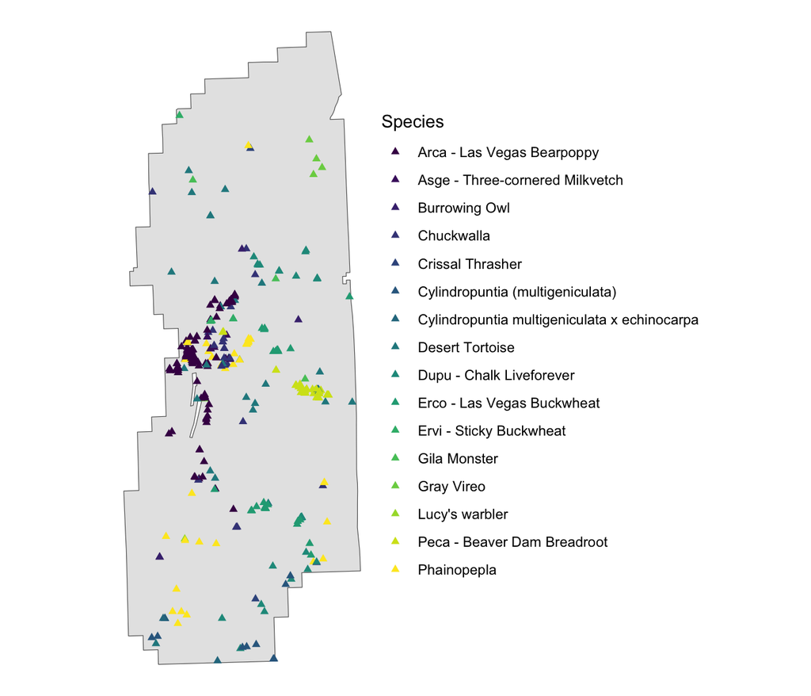

```r
GoldButteSpeciesMap <- ggplot() +
  theme_void() +
  geom_spatvector(data = GB_Boundary) +
  geom_spatvector(data = GB_Species, mapping = aes(colour = GB_Species$ObservedSp), shape = 17) +
  scale_color_viridis(discrete = TRUE, name = "Species")
GoldButteSpeciesMap
```

## Question 2

1. Subset the observation data to create a dataset containing only the Las Vegas Bearpoppy. b) Plot Las Vegas Bearpoppy occurrence on top of the distance to roads layer (from the D2Roads.tif file), C) with the plot cropped to the gold butte boundary.

```r
LV_Bearpoppy <- subset(GB_Species, GB_Species$ObservedSp == "Arca - Las Vegas Bearpoppy")
length(LV_Bearpoppy$ObservedSp)
```

```
## [1] 160
```

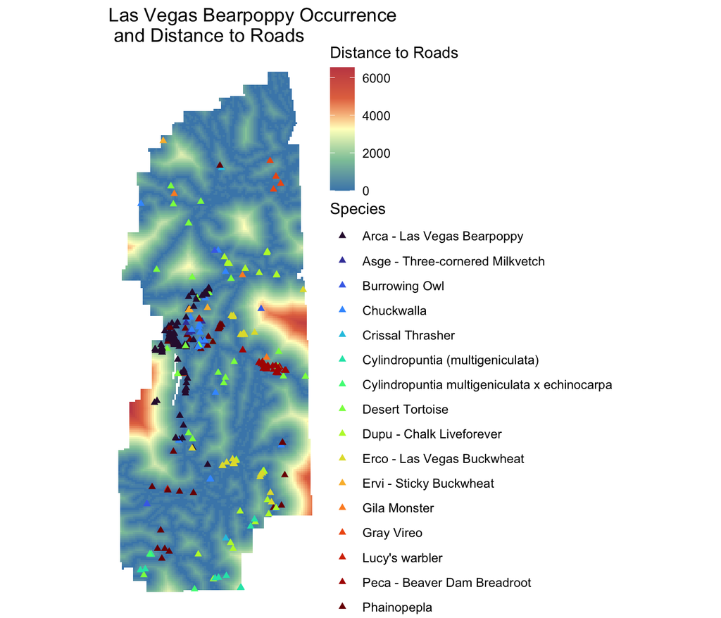

```r
D2Rds <- rast("GoldButte/D2Roads.tif")
D2Rds_crop <- crop(D2Rds, GB_Boundary)
D2Rds_plot <- ggplot() +
  theme_void() +
  geom_spatraster(data = D2Rds_crop) +
  scale_fill_whitebox_c(palette = "muted", name = "Distance to Roads") +
  geom_spatvector(data = GB_Species, mapping = aes(colour = GB_Species$ObservedSp), shape = 17) +
  scale_color_viridis(discrete = TRUE, name = "Species", option = "turbo") +
  ggtitle("Las Vegas Bearpoppy Occurrence \n and Distance to Roads")
D2Rds_plot
```

## Question 3 Using the observation data for the Bearpoppy from question 2. A) Model the Number of Bearpoppy’s observed at each of the points (Nobs) as a function of the distance to roads using a glm. B) Interpreting this model output is there a signification association of Bearpoppy with roads?

```r
newLVB_pts <- terra::extract(D2Rds_crop, LV_Bearpoppy, bind =T)
LVB_glm <- glm(Nobs ~ D2Roads, data = newLVB_pts)
```

```r
summary(LVB_glm)
```

```
##
## Call:
## glm(formula = Nobs ~ D2Roads, data = newLVB_pts)
##
## Coefficients:
##               Estimate Std. Error t value Pr(>|t|)
## (Intercept) 11.9598041  0.2285281   52.33   <2e-16 ***
## D2Roads     -0.0039283  0.0003063  -12.82   <2e-16 ***
## ---
## Signif. codes:  0 '***' 0.001 '**' 0.01 '*' 0.05 '.' 0.1 ' ' 1
##
## (Dispersion parameter for gaussian family taken to be 5.706836)
##
##     Null deviance: 1834.64  on 158  degrees of freedom
## Residual deviance:  895.97  on 157  degrees of freedom
##   (1 observation deleted due to missingness)
## AIC: 732.13
##
## Number of Fisher Scoring iterations: 2
```

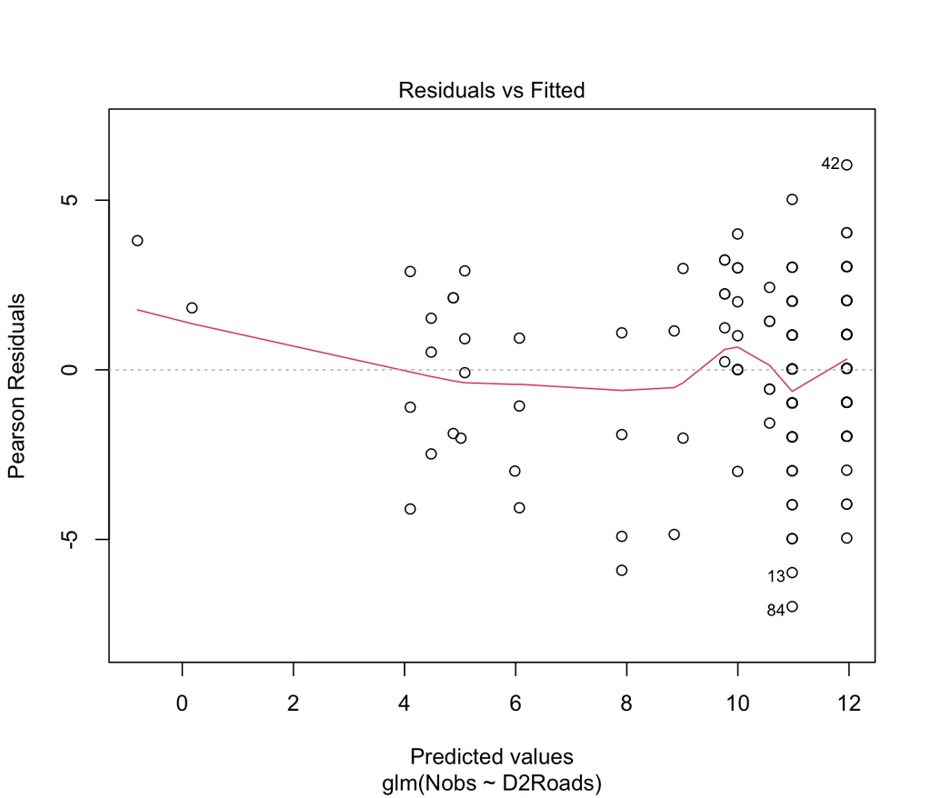

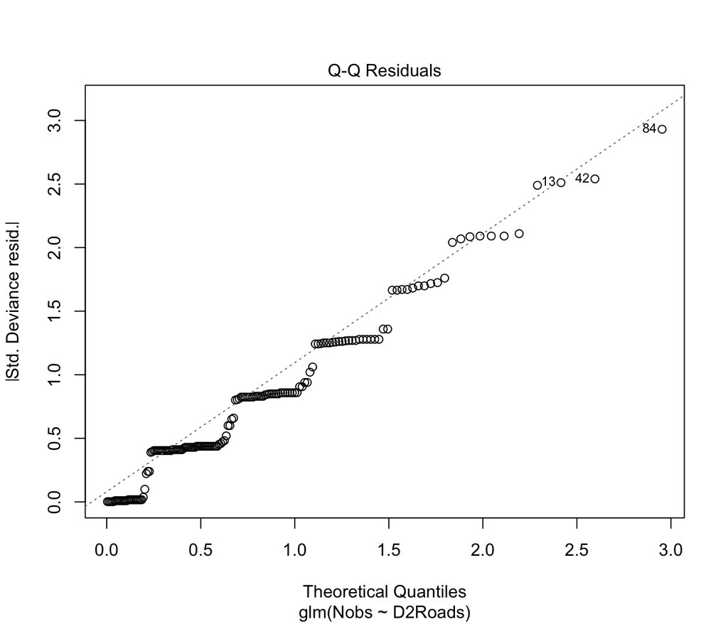

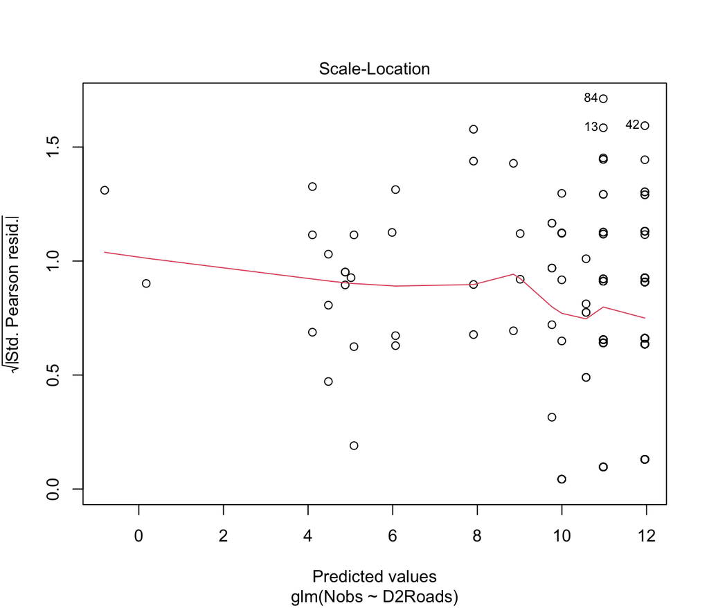

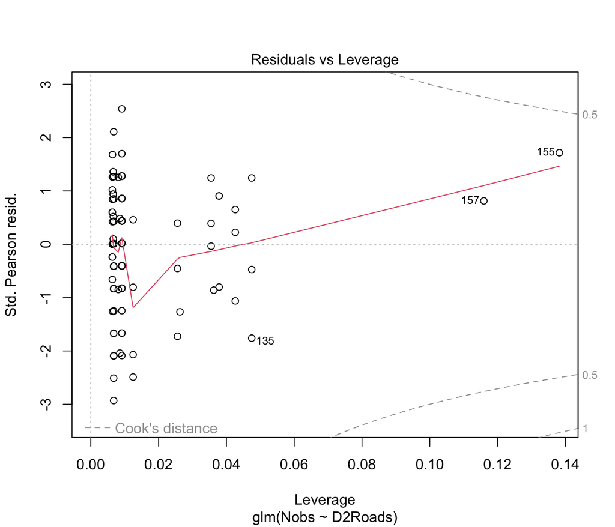

```r
plot(LVB_glm)
```

```r
## There is a highly significant association of Bearpoppy with roads according to this model.
```